# Plot Cumulative Incidence and Survival Curves

Sahir Rai Bhatnagar

2026-09-03

## Introduction

In this short vignette, we will introduce the `plot` method for `absoluteRisk` objects. This method allows you to plot cumulative incidence (CI) or survival curves as a function of time and a given covariate profile. More specifically, the cumulative incidence is given by:

$$CI(x, t) = 1 - exp\left[ - \int_0^t
h(x, u) \textrm{d}u \right]$$
where \( h(x, t) \) is the hazard function, \( t \) denotes the numerical value (number of units) of a point in prognostic/prospective time and \( x \) is the realization of the vector \( X \) of variates based on the patient’s profile and intervention (if any). And the survival function is given by
$$S(x, t) = 1 - CI(x,t) = exp\left[ - \int_0^t
h(x, u) \textrm{d}u \right]$$

## Analysis of the `brcancer` dataset

To illustrate hazard function plots, we will use the breast cancer dataset which contains the observations of 686 women taken from the [`TH.data`](https://cran.r-project.org/package=TH.data) package. This dataset is also available from the `casebase` package. In the following, we will show the CI curve for several covariate profiles.

```r
library(casebase)
library(survival)
library(ggplot2)


data("brcancer")
mod_cb_glm <- fitSmoothHazard(cens ~ estrec*log(time) +
                                  horTh +
                                  age +
                                  menostat +
                                  tsize +
                                  tgrade +
                                  pnodes +
                                  progrec,
                              data = brcancer,
                              time = "time", ratio = 10)

summary(mod_cb_glm)
```

### Plotting Cumulative Incidence Curves

We can use the `plot` method for objects of class `absRiskCB`, which is returned by the `absoluteRisk` function, to plot cumulative incidence curves. For example, suppose we want to compare the cumulative incidence curves of the 1st and 50th individuals in the `brcancer` dataset. We first call the `absoluteRisk` function and specify the `newdata` argument. Note that since time is missing, the risk estimate is calculated at the observed failure times.

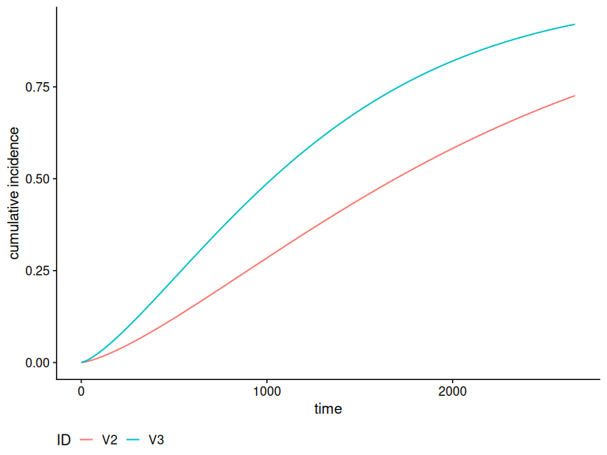

```r
smooth_risk_brcancer <- absoluteRisk(object = mod_cb_glm,
                                     newdata = brcancer[c(1,50),])

class(smooth_risk_brcancer)
plot(smooth_risk_brcancer)
```

These curves can be further customized. For example, suppose we want to change the legend title and legend keys:

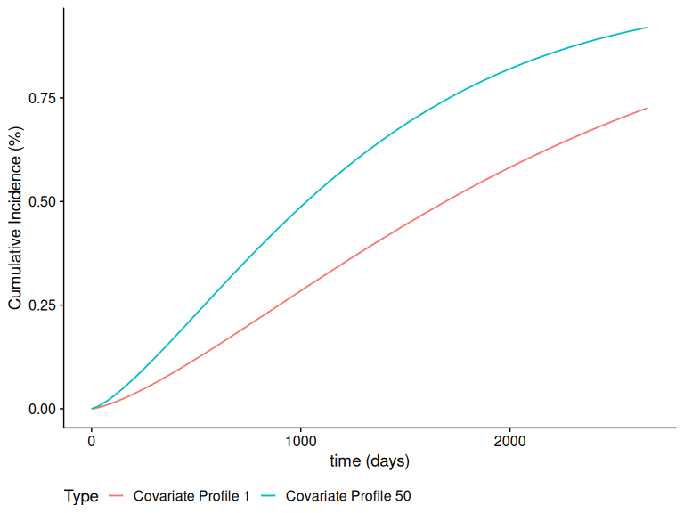

```r
plot(smooth_risk_brcancer,
     id.names = c("Covariate Profile 1","Covariate Profile 50"),
     legend.title = "Type",
     xlab = "time (days)",
     ylab = "Cumulative Incidence (%)")
```

The call to `plot` on a `absRiskCB` object returns a `ggplot2` object, and therefore can be used downstream with other `ggplot2` functions. For example, suppose we want to change the theme:

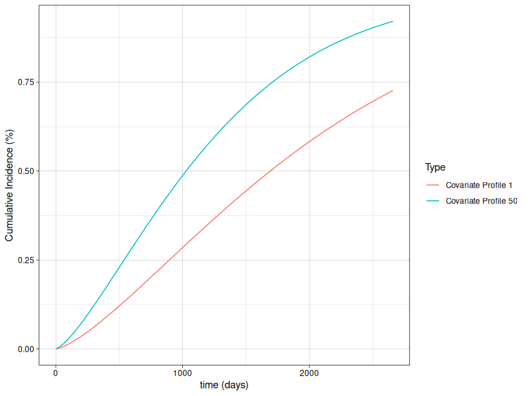

```r
plot(smooth_risk_brcancer,
     id.names = c("Covariate Profile 1","Covariate Profile 50"),
     legend.title = "Type",
     xlab = "time (days)",
     ylab = "Cumulative Incidence (%)") + ggplot2::theme_linedraw()
```

### Using `graphics::matplot`

By default, the `plot` method uses `ggplot2` to produce the curves. Alternatively, you can use `graphics::matplot` by specifying `gg = FALSE`. This option is particularly useful if you want to add the cumulative incidence curve to an existing plot, e.g., adding the adjusted smooth curve to a Kaplan-Meier curve. In this example, we calculate the cumulative incidence for a *typical* individual in the dataset:

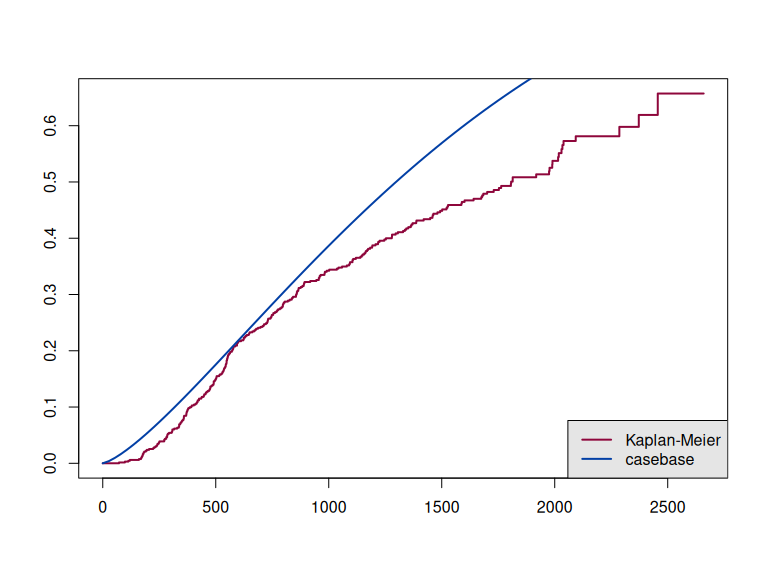

```r
cols <- c("#8E063B","#023FA5")

smooth_risk_typical <- absoluteRisk(object = mod_cb_glm, newdata = "typical")
y <- with(brcancer, survival::Surv(time, cens))
plot(y, fun = "event", conf.int = F, col = cols[1], lwd = 2)
plot(smooth_risk_typical, add = TRUE, col = cols[2], lwd = 2, gg = FALSE)
legend("bottomright",
       legend = c("Kaplan-Meier", "casebase"),
       col = cols,
       lty = 1,
       lwd = 2,
       bg = "gray90")
```

## Survival Curves

We can also easily calculate and plot survival curves by specifying `type = 'survival'` in the call to `absoluteRisk`. The corresponding call to `plot` is the same as with cumulative incidence curves:

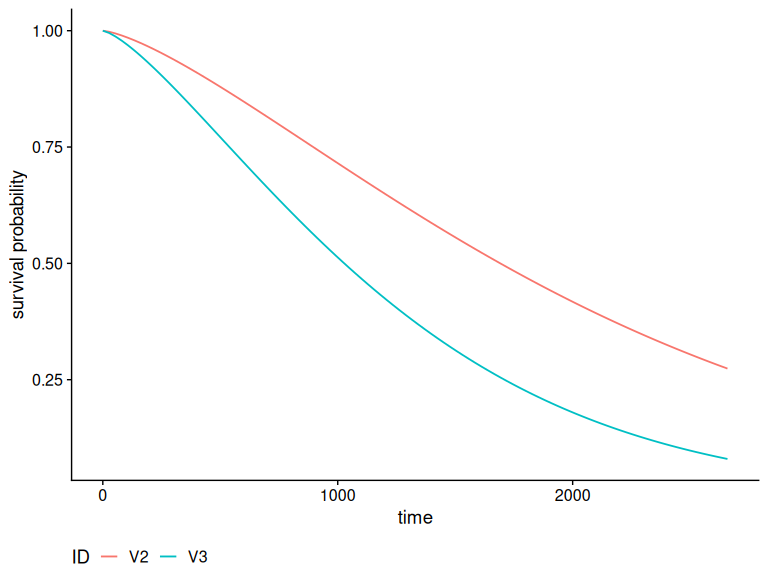

```r
smooth_surv_brcancer <- absoluteRisk(object = mod_cb_glm,
                                     newdata = brcancer[c(1,50),],
                                     type = "survival")

plot(smooth_surv_brcancer)
```

## Other families

### `glmnet`

We can also plot cumulative incidence curves for other families. For example, using the `family = "glmnet"`, we can plot the cumulative incidence curves for the first 10 individuals in the `brcancer` dataset, using the tuning parameter which minimizes the 10-fold cross-validation error ($\lambda_{min}$):

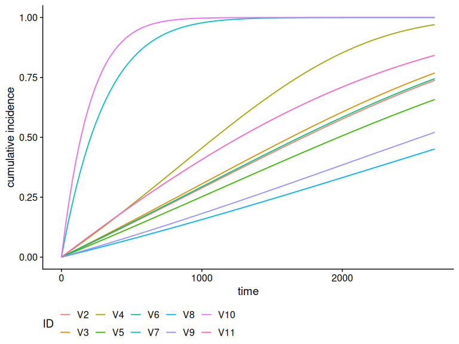

```r
mod_cb_glmnet <- fitSmoothHazard(cens ~ estrec*time +
                                     horTh +
                                     age +
                                     menostat +
                                     tsize +
                                     tgrade +
                                     pnodes +
                                     progrec,
                                 data = brcancer,
                                 time = "time",
                                 ratio = 1,
                                 family = "glmnet")

smooth_risk_glmnet <- absoluteRisk(object = mod_cb_glmnet,
                                   newdata = brcancer[1:10,],
                                   s = "lambda.min")
plot(smooth_risk_glmnet)
```

### `gam`

Here we produce the same plot but for `family = "gam"` for generalised additive models.

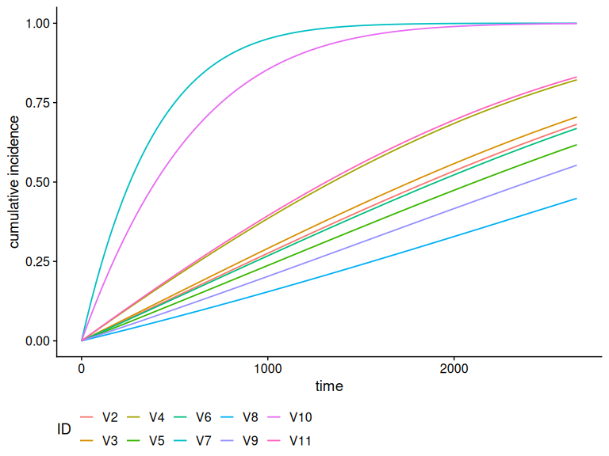

```r
mod_cb_gam <- fitSmoothHazard(cens ~ estrec + time +
                                     horTh +
                                     age +
                                     menostat +
                                     tsize +
                                     tgrade +
                                     pnodes +
                                     progrec,
                                 data = brcancer,
                                 time = "time",
                                 ratio = 1,
                                 family = "gam")

smooth_risk_gam <- absoluteRisk(object = mod_cb_gam,
                                newdata = brcancer[1:10,])
plot(smooth_risk_gam)
```